# ISL Chapter 4: Lab & Applied Exercises

Tried increasing K, and it turns out that we can get the test error rate as low as 0.0865.

11. In this problem, you will develop a model to predict whether a given car gets high or low gas mileage based on the Auto data set.
1. Create a binary variable, mpg01, that contains a 1 if mpg contains a value above its median, and a 0 if mpg contains a value below its median. You can compute the median using the median() function. Note you may find it helpful to use the data.frame() function to create a single data set containing both mpg01 and the other Auto variables.

```r
data(Auto)
str(Auto)
```

```
## 'data.frame':    392 obs. of  9 variables:
##  $ mpg         : num  18 15 18 16 17 15 14 14 14 15 ...
##  $ cylinders   : num  8 8 8 8 8 8 8 8 8 8 ...
##  $ displacement: num  307 350 318 304 302 429 454 440 455 390 ...
##  $ horsepower  : num  130 165 150 150 140 198 220 215 225 190 ...
##  $ weight      : num  3504 3693 3436 3433 3449 ...
##  $ acceleration: num  12 11.5 11 12 10.5 10 9 8.5 10 8.5 ...
##  $ year        : num  70 70 70 70 70 70 70 70 70 70 ...
##  $ origin      : num  1 1 1 1 1 1 1 1 1 1 ...
##  $ name        : Factor w/ 304 levels "amc ambassador brougham",..: 49 36 231 14 161 141 54 223 241 2 ...
```

```r
auto_cors <- get.cors(Auto, 9)

# create a binary variable for mpg above median = 1, and below median = 0.
mpg_median <- median(Auto$mpg)
Auto <- Auto %>%
  mutate(mpg01 = if_else(mpg < mpg_median, 0, 1))

Auto$mpg01 <- as.factor(Auto$mpg01)
```

2. Explore the data graphically in order to investigate the association between mpg01 and the other features. Which of the other features seem most likely to be useful in predicting mpg01? Scatterplots and boxplots may be useful tools to answer this question. Describe your findings.

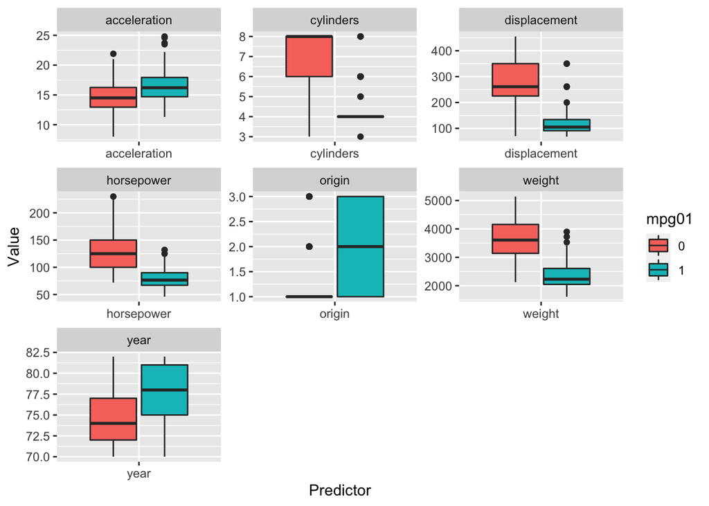

```r
# first step in exploring - let's look at whether there are any obvious distinctions in single features depending on if the mileage is high (mpg01 = 1) or low (mpg01= 0):

# reference: https://www.r-graph-gallery.com/265-grouped-boxplot-with-ggplot2.html#:~:text=A%20grouped%20boxplot%20is%20a,called%20in%20the%20fill%20argument.

create.boxplot.facet <- function(df, outcome.var) {
 # pivot data to long form
df.long <- df %>%
  pivot_longer(-c(name, mpg, outcome.var), names_to = "Predictor", values_to = "Value")
df.long <- df.long[, c("Predictor", outcome.var, "Value")] # reorder columns

# create facet of plots
boxplot <- ggplot(df.long, aes_string(x="Predictor", y="Value", fill=outcome.var)) +
  geom_boxplot() +
  facet_wrap(~Predictor, scales = "free")
}

test.df <- Auto
test.vars <- "mpg01"

class.boxplot <- create.boxplot.facet(test.df, test.vars)
class.boxplot
```

Hm, there apperas to be strong positive and negative associations with having high vs. low mileage. Acceleration, year, and origin appear to have notable positive relationships, whereas cylinder, displacement, horsepower, and weight have negative relationships. Let’s explore this further using classification models (log regression, LDA, QDA, and KNN) … But first:

3. Split the data into a training set and a test set.

```r
# create a vector of logical values that assigns odd numbers to training and even numbers to test
train.even <- ((as.numeric(rownames(Auto)) %% 2) == 0)
test.odd <- ((as.numeric(rownames(Auto)) %% 2) != 0)

# use this to create a subset of training data and test data
Auto.train <- Auto[train.even,]
Auto.test <- Auto[test.odd,]

# create a single-var vector of test predictions from this data
Auto.test.outcomes <- Auto.test$mpg01
```

Perform LDA on the training data in order to predict mpg01 using the variables that seemed most associated with mpg01 in (b). What is the test error of the model obtained?